# 第12回 論文のコードを読む

# 6. 似た銀河は、どう集まるか？

## 似た銀河どうしは？

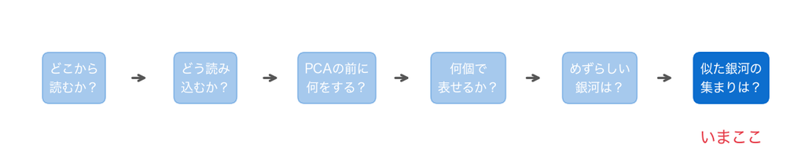

- めずらしい銀河は見た。では、似た形の銀河どうしは、どう集まるか

## 得点で、グループに分ける

6節 ① AP●○

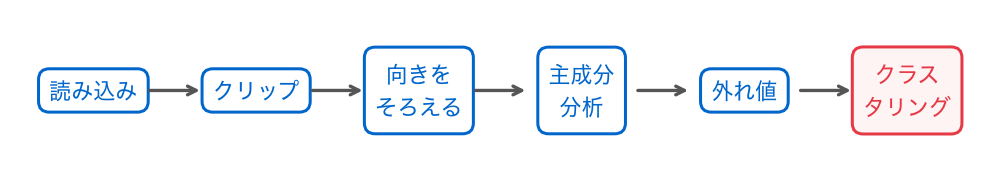

- 著者は、固有銀河の得点`scores`（10列）で、銀河をグループに分けている

## Affinity Propagation

6節 ① AP●●

- 著者が使っているのは、Affinity Propagation（アフィニティ・プロパゲーション）
- k-meansと違い、グループの数を先に決めない
- 各点が「自分の代表にふさわしい点」を互いに推しあい、代表と、そこに集まるグループが決まる

## お手本：クラスタリングのセル

6節 ② セル33●○

```python
# 著者のセル33をそのまま写したもの
from sklearn.cluster import AffinityPropagation
clust=AffinityPropagation(damping=0.9,convergence_iter=100,max_iter=1000)
clust=clust.fit(scores)
```

```python
print(len(np.unique(clust.labels_)), 'グループ')
```

[output not shown]

## 百四十数個のグループ

6節 ② セル33●●

- 百四十数個のグループができる
- この数は、実行するたびに1つ2つ揺れることがある

## なぜ揺れる？

6節 ③ シード●○○

- 著者のセルは、乱数のシード（`random_state`）を決めていない
- 前回の`KMeans`でも、`random_state=0`で乱数のシードを決めた

## お手本：乱数のシードを決める

6節 ③ シード●●○

```python
from sklearn.cluster import AffinityPropagation
clust = AffinityPropagation(damping=0.9, convergence_iter=100,
                            max_iter=1000, random_state=0).fit(scores)
print(len(np.unique(clust.labels_)), 'グループ')
```

- 著者のセルに`random_state=0`を足しただけ

## 146グループ

6節 ③ シード●●●

```
146 グループ
```

- 何度実行しても、146グループ
- ここから先は、この`clust`を使う

## グループの要約のセル

6節 ④ セル34●○○○

```python
# 著者のセル34をそのまま写したもの
import os

l=clust.labels_
G=pd.DataFrame(dict(l=l)).groupby("l").l.count()
df=pd.DataFrame(dict(l=G.index,cnt=G.values))
df=df.sort_values("cnt",ascending=False)
df=df.head(100)

print("labels",len(np.unique(l)))
print("min",np.min(G))
print("max",np.max(G))
print("mean",np.median(G))
print("median",np.median(G))
```

- セル34の前半。後半の、画像をファイルに保存する処理は写していない

## かたまりで読む

6節 ④ セル34●●○○

- `G`：グループごとの銀河の数（グループの大きさ）
- `df`：大きい順に並べた表（後半で使う）
- 最後の5行：グループの数、大きさの最小・最大・平均・中央値を表示

## 大きさの要約

6節 ④ セル34●●●○

```
labels 146
min 1
max 143
mean 1.0
median 1.0
```

- いちばん小さいグループは1個、いちばん大きいグループは143個

## 平均が1個？

6節 ④ セル34●●●●

```
mean 1.0
median 1.0
```

- 平均（mean）も中央値（median）も、1.0
- 1,222個を146グループに分けて、平均が1個で、よいのか

## TODO⑤：表示を確かめる

6節 ⑤ 食い違い●○○○○

```python
# TODO: グループの大きさの平均と中央値を表示する
# ヒント: print('mean', round(np.mean(G), 2))
#         print('median', np.median(G))
...
```

- 著者のセル34の`print("mean",…)`の行を、よく読む

## やってみよう：6節とTODO⑤

6節 ⑤ 食い違い●●○○○

- 6節の、著者のセル33・34と、お手本を実行する
- TODO⑤で、平均と中央値を出し直す

動画の人は、ここで一時停止。

## 答え合わせ：TODO⑤

6節 ⑤ 食い違い●●●○○

```python
print('mean', round(np.mean(G), 2))
print('median', np.median(G))
```

```
mean 8.37
median 1.0
```

## meanと書いて、中央値

6節 ⑤ 食い違い●●●●○

```python
print("mean",np.median(G))
```

- 著者の行は、平均（mean）と書きながら、`np.median`（中央値）を計算していた
- 本当の平均は8.37、中央値は1

## 見出しと中身が、食い違う

6節 ⑤ 食い違い●●●●●

- 表示の見出しと、計算の中身が食い違っていた
- 表示を信じたままだと、「グループの大きさは平均1個」と誤って読む
- 数は、自分で計算して確かめる

## 平均と中央値

6節 ⑥ 平均と中央値●○○○○

グループの大きさを$n_1, \dots, n_{146}$とすると

$$\bar n = \frac{1}{146}\sum_{g=1}^{146} n_g = \frac{1222}{146}$$

- 平均は、銀河の数をグループの数で割った値
- 中央値は、大きさを小さい順に並べたときの真ん中

## なぜ、こんなに違う？

6節 ⑥ 平均と中央値●●○○○

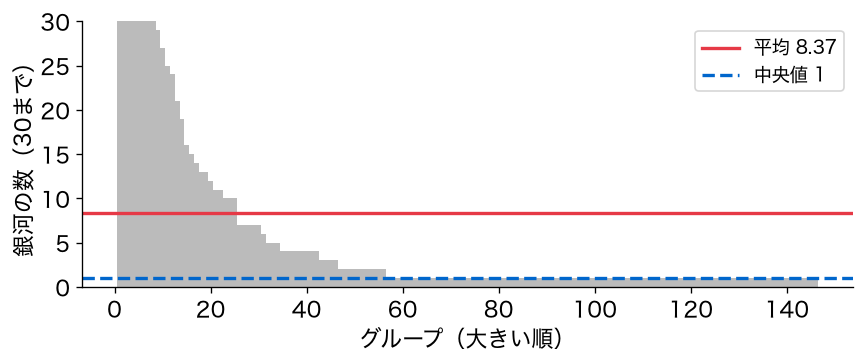

- 平均8.37と中央値1。棒は大きい順で、縦は30で切ってある

## お手本：グループの大きさを数える

6節 ⑥ 平均と中央値●●●○○

```python
print((G == 1).sum(), '個のグループが、銀河1個だけ')
big = G[G >= 10]
print(len(big), '個のグループが10個以上で、合わせて', big.sum(), '個')
```

```
90 個のグループが、銀河1個だけ
25 個のグループが10個以上で、合わせて 1012 個
```

## 90グループが、銀河1個だけ

6節 ⑥ 平均と中央値●●●●○

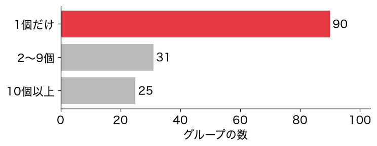

- 146グループのうち90グループは、どこにも似ていない1個だけのグループ
- だから、中央値は1になる

## 25グループに、1,012個

6節 ⑥ 平均と中央値●●●●●

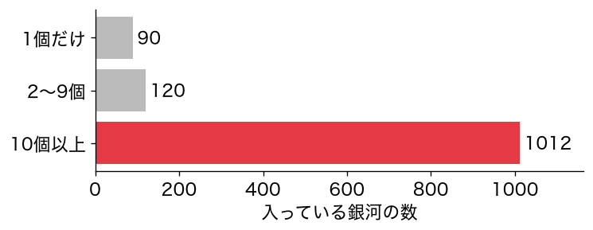

- 10個以上の銀河が入ったグループは25個。合わせて1,012個
- 多くの銀河は、25個ほどの大きなグループに集まる

## いちばん大きいグループは？

6節 ⑦ 大きいグループ●○○

- グループの数は分かった。中身は、どんな銀河か
- いちばん大きいグループを、画像で見る

## お手本：いちばん大きいグループ

6節 ⑦ 大きいグループ●●○

```python
top = indexes[clust.labels_ == G.idxmax()]
make_image(top[:30], (5, 6))
plt.show()
```

- `G.idxmax()`：`G`の値がいちばん大きい所の番号（グループの番号）

## 小さく丸い銀河

6節 ⑦ 大きいグループ●●●

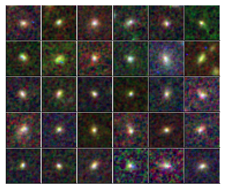

- 小さく丸い、中心の明るい銀河。得点が近いと、目で見ても似ている

## 答え：論文の主張

6節 ⑧ 答え●○○

- 10個の固有銀河で、形の散らばりの96%を表せた。論文の約12個に近い
- 3個で9割、第1主成分だけで寄与率0.763
- 得点で、似た形の銀河のグループに分けられた

## 答え：気をつける所①

6節 ⑧ 答え●●○

- ファイルの並び順（`glob`）と、乱数のシードで、結果が揺れる
- 並べ方とシードを、決めておく

## 答え：気をつける所②

6節 ⑧ 答え●●●

- 著者の関数は、渡した配列をその場で書きかえることがある。写しを渡す
- 表示の見出しと中身が食い違うことがある（meanと書いて中央値）。数は自分で計算する

## まだ言えないこと①：前処理

6節 ⑨ まだ言えないこと●○○

- 向きをそろえる段がなかったら、固有銀河の数はどう変わるか
- 課題で確かめる

## まだ言えないこと②：1万個

6節 ⑨ まだ言えないこと●●○

- 論文は約1万個。今日は、その一部の1,222個で確かめた

## まだ言えないこと③：グループの数

6節 ⑨ まだ言えないこと●●●

- 146グループは、多すぎないか
- 分け方の良し悪しを、数で測るには

# まとめ

## 今日の道筋を振り返る

⑥ 振り返る●○○○○○

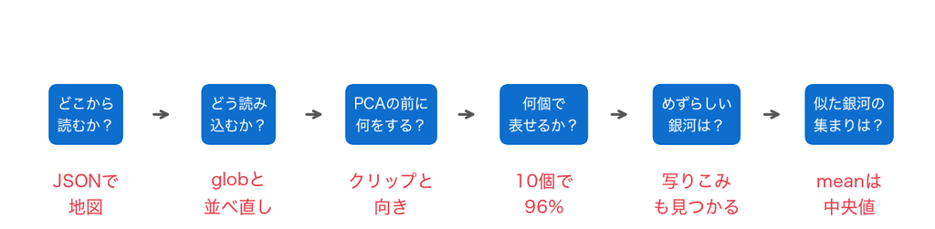

- 6つの小さな問いに答えて、論文の主張を確かめた

## 今日の歩み

⑥ 振り返る●●○○○○

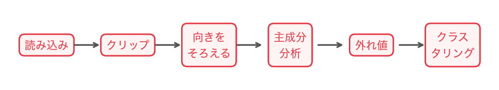

著者のパイプラインの6段を、ブロックごとに読んで動かした

## 今日持ち帰る1文

⑥ 振り返る●●●○○○

他人のコードは、見出しで地図を作り、関数を作るブロックと処理のブロックに分けて読む。動かして数を出し直し、並び順・乱数のシード・書きかえ・表示の食い違いのように、結果が揺れたり誤ったりする所を確かめてから、論文の主張と比べる。

## 今日の要点①：読み方

⑥ 振り返る●●●●○○

- `.ipynb`はJSON。見出しを並べて、ノートの地図を作る
- 関数を作るブロックと、処理のブロックに分けて読む
- 全部は読まない。主張に要るセルを順に読む

## 今日の要点②：再現

⑥ 振り返る●●●●●○

- ファイルの並び順と乱数のシードを、決めておく
- 渡した配列が書きかわらないよう、写し（`.copy()`）を渡す
- 表示の見出しを信じず、数は自分で計算して確かめる

## 今日の要点③：Python

⑥ 振り返る●●●●●●

- `json.load`、`glob`、`np.load`、`plt.imread`、`os.chdir`、`!`で始まる行
- `.copy()`、`np.argsort`、`random_state`

## 課題の出し方

⑦ このあと●○○○

- ノートの最後の「課題（提出）」に取り組む
- 応用②の答えと応用③の文章を、LACSに入力して提出（＝出席。期限なし）
- AIを使ってもよい。何を聞いて、どう直したかを1行書く

## 次回予告：分け方の良し悪し

⑦ このあと●●○○

- 今日のクラスタリングは、146ものグループに分かれた
- 前回の国のグループ分けでも、3つという数は、こちらで決めた

## 次回の問い

⑦ このあと●●●○

その分け方は妥当か？ グループの数をいくつにすべきかを、根拠をもって言えるか？

## このあと：課題へ

⑦ このあと●●●●

ノートの「課題（提出）」へ。向きをそろえる段を外して、固有銀河の数を数え直します。

# ここから先は解答

## 課題のあとで見る

課題（提出）に取り組んでから見てください。動画の人は、ここで一時停止。

## 応用①：向きをそろえない

```python
L, U = np.quantile(raw_data, [0, .99])
clip_only = np.clip(raw_data, L, U)        # 向きをそろえない
pca_r = PCA(.96).fit(clip_only)
print(pca_r.n_components_, pca_r.explained_variance_ratio_[:3].round(3))
make_image_pre(pca_r.components_[:9].copy(), (3, 3), '向きをそろえない')
make_image_pre(pca.components_[:9].copy(), (3, 3), '向きをそろえる')
plt.show()
```

```
14 [0.747 0.114 0.025]
```

## 2段のうち、1段だけ

- `normalise_all`の中の、`np.quantile`と`np.clip`の2行だけを使う
- `rotation`を呼ばないので、向きはそろわない

## 応用②：答えは14

```python
print('答え:', pca_r.n_components_)
```

```
答え: 14
```

- 向きをそろえると10個、そろえないと14個

## 固有銀河の形が変わる

[figure not shown]

- 向きをそろえないときの固有銀河。斜めや横に伸びた形が混ざる

## 向きの違いに、成分を使う

- 同じ伸びた形を、いろいろな向きで表すための成分が要る
- そのぶん、96%に要る数が10個から14個に増える

## 応用③：模範例

向きをそろえたときは10個の固有銀河で96%を表せましたが、そろえないと14個が要りました。そろえないときの固有銀河には、同じ伸びた形を、いろいろな向きで表すための成分が混ざります。論文の「約12個」という少なさは、向きをそろえる段を含めた数なので、論文の数と比べるときは、この1段を省かずに再現する必要があります。

## 書き方の型

- 1文目：数の比較（10個と14個）
- 2文目：なぜ増えるか（向きの違いに成分を使う）
- 3文目：論文と比べるときの注意

# 発展（任意）

## 脳の画像にも、同じパイプライン

- 医用画像にも、読み込み → 前処理 → クラスタリング、のパイプラインがある
- Abrahamほか（2014, Frontiers in Neuroinformatics）は、安静にしている人の脳のfMRIを、似た動きをする場所ごとの区画に分けた

## 書き直した版で、再現する

- 論文のコードは古い版の道具で書かれていて、今は動かない
- 同じ手順を、今の道具（nilearnとscikit-learn）で書き直した版で、論文の図を再現する

## お手本：脳の画像を読む

```python
!pip install -q nilearn
from nilearn import datasets, plotting
from nilearn.maskers import NiftiMasker
import nibabel as nib

adhd = datasets.fetch_adhd(n_subjects=1)        # 1人分を取ってくる
img = nib.load(adhd.func[0])                    # NIfTI を読む
print(img.shape)                                # 縦・横・高さ・時間
```

[output not shown]

- NIfTI（`.nii.gz`）は、医用画像の形式。縦×横×高さ×時間の4次元の配列

## 61×73×61×176

- 61×73×61の立体（1つの画素は3mm角）を、2秒ごとに176回撮っている
- 1人分は約44MB

## お手本：場所ごとの表にする

```python
# 脳の中だけを取り出し（マスク）、少しぼかし、場所ごとに標準化する
masker = NiftiMasker(mask_strategy='epi', smoothing_fwhm=6,
                     standardize='zscore_sample')
X = masker.fit_transform(img)                   # 時間 × 脳の場所
print(X.shape)
```

[output not shown]

- 176時点 × 62,546か所の表。1列が、脳の1か所（ボクセル）の時間の動き

## お手本：区画に分ける

```python
from sklearn.feature_extraction.image import grid_to_graph
from sklearn.cluster import FeatureAgglomeration

mask = masker.mask_img_.get_fdata().astype(bool)
conn = grid_to_graph(*mask.shape, mask=mask)  # となりだけつなぐ
ward = FeatureAgglomeration(n_clusters=100, connectivity=conn,
                            linkage='ward').fit(X)
labels = masker.inverse_transform(ward.labels_ + 1)   # 脳の形に戻す
plotting.plot_roi(labels, title='Ward 法で100の区画',
                  display_mode='xz', cut_coords=(0, 0))
plotting.show()
```

[output not shown]

## ひとつながりの区画

- 色の1つ1つが、時間の動きが似ている場所をまとめた区画
- 「となり合う場所だけをつなぐ」条件（`connectivity`）で、どの区画もひとつながりの塊になる
- 列（場所）をまとめるので、`FeatureAgglomeration`を使う

## 試すなら

- `n_clusters`を20や500に変えて、区画の細かさを見る
- つながりの条件なしのk-means（`MiniBatchKMeans(n_clusters=100).fit(X.T)`）では、区画がばらばらに散らばる

## おわり

- 今日は、固有銀河の論文を、著者のコードを読んで動かし、確かめた
- 地図を作り、ブロックで読み、数を出し直して、揺れや食い違いに気をつけた